# statsbykj

Kara Godsey

12/13/2020

# Welcome

I am a graduate student at Bowling Green State University studying Applied Statistics. In May 2020, I earned a bachelor’s degree in Mathematics and Actuarial Science from Grace College.

I have a passion for the intersection of math and sports, and hope to make a career in the sports world one day. My preferred sport is baseball, but college football, hockey, and golf are also pretty high on my list.

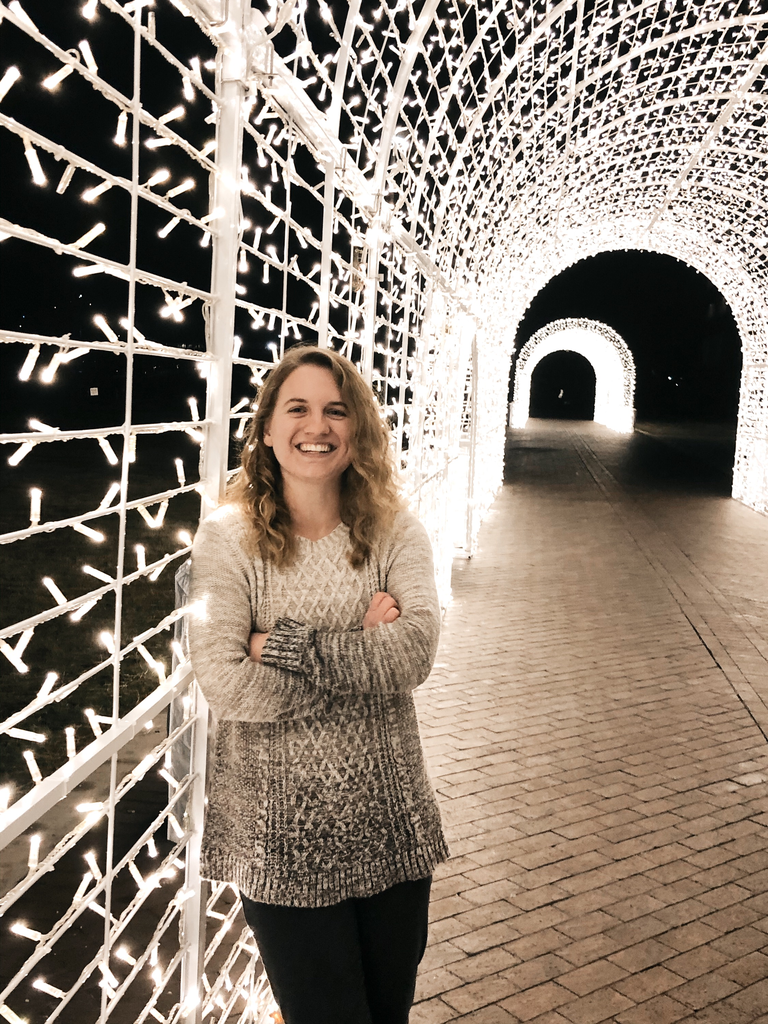

# Articles

This section will hold links to my Diamond Digest articles, as well as future articles for Softball America.

## Diamond Digest

I joined the staff of Diamond Digest in July 2020, primarily providing news and analysis related to the Miami Marlins. Below are a few examples of my work:

[Pablo Lopez: The Breakout Arm No One Saw Coming](https://diamond-digest.com/2020/09/03/pablo-lopez-the-breakout-arm-no-one-saw-coming/)

[Offseason Outlook: Miami Marlins](https://diamond-digest.com/2020/11/17/offseason-outlook-miami-marlins/)

[NLDS Preview: Familiar Foe for the Fish](https://diamond-digest.com/2020/10/06/nlds-preview-familiar-foe-for-the-fish/)

## Softball America

In January 2021, I will begin an internship with Softball America, providing weekly content that includes features, profiles, and rankings. Check back soon for examples of my work.

# Projects

This section will hold links to past projects, most notably the Crossroads Baseball project.